# Time series of Environmental Sensors: the basics

J-AIL course: Introduction to Time Series Analysis in Limnology

Lluís Gómez Gener[^1]

31/3/2022

# Introduction

In this session we will introduce some basic techniques commonly used to import, explore, and handle row sensor TS. This session will be divided in different subsections:

- Data import
- Dates and times
- Data exploration
- Data visualization

# Resources

## Import, dates and tims and basic exploration

- On-line course “R for Data Science” *Data import* [Website](https://r4ds.had.co.nz/data-import.html).
- On-line course “R for Data Science” *Dates and times* [Website](https://r4ds.had.co.nz/dates-and-times.html).
- DataCamp Online Course *Time Series Analysis in R* [Website](https://app.datacamp.com/learn/courses/time-series-analysis-in-r).

## Advanced analyasis

- You can find a quite extensive tutorial at *Using R for Time Series Analysis* [Website](https://a-little-book-of-r-for-time-series.readthedocs.io/en/latest/src/timeseries.html)
- You can find a list of R packages for analysing time series data on the *CRAN Time Series Task View webpage* [Website](https://cran.r-project.org/web/views/TimeSeries.html)

And two books:

- Box et al. 2016 *Time Series Analysis: forecasting and control. 5th Edition* [Website](https://www.wiley.com/en-ie/Time+Series+Analysis:+Forecasting+and+Control,+5th+Edition-p-9781118675021).
- Shumway H. and Stoffer D. et al. 2011 *Time Series Analysis and Its Applications With R Examples. 3rd Edition* [Website](https://link.springer.com/book/10.1007/978-3-319-52452-8).

## Cheat sheets

- *lubridate Cheat Sheet* [Website](https://rawgit.com/rstudio/cheatsheets/main/lubridate.pdf).
- *dplyr Cheat Sheet* [Website](https://gauss.inf.um.es/tabular/www/data-transformation.pdf).
- *ggplot2 Cheat Sheet* [Website](https://www.maths.usyd.edu.au/u/UG/SM/STAT3022/r/current/Misc/data-visualization-2.1.pdf).

# 1. Data import (dealing with Dates and Times)

Before starting, we need to load some packages:

```r
library(tidyverse)
library(lubridate)
library(dplyr)
library(ggplot2)
library(imputeTS)
library(miceRanger)
library(naniar)
library(visdat)
library(akima)
library(colorRamps)
```

We also need to set up the working directory (i.e., folder where where R will find the files or/and store the outputs). This path MUST correspond to the path where your data is stored:

```r
setwd("C:/Users/lgomez/Dropbox/Teaching and research GENERAL/00_Teaching general/Introduction to time series analysis (JAIL)")
getwd()
```

```
## [1] "C:/Users/lgomez/Dropbox/Teaching and research GENERAL/00_Teaching general/Introduction to time series analysis (JAIL)"
```

Now we are ready to read an external TS file. However, as most sensor data is recorded below the “day” frequency (we normally define HF as data recorded at a frequency equal or lower than 1 hour) we need to make sure that R understands what are the Date and Time (and Date&Time) variables of our TS.

VERY IMPORTANT: How the “date and time” in your input TS file (normally a csv. created or edited with Ms. Excel) should look like?

2016-01-01 00:00:00 yyyy-mm-dd hh:mm:ss

if in Ms. Excel you only independent columns for “date” and “time” you can use the following code to merge them into the “datetime” format:

`=CONCATENAR(TEXTO(A2,"aaaa-mm-dd")," ",TEXTO(B2,"hh:mm:ss"))`

Let’s import an external TS and have a look how the Date and Time variables look like. For this we will use the function `read_csv()`, which is part of the core `tidyverse`.

```r
vau <- read_csv('00_course datasets/vau_all_2019.csv')
```

A date-time object is basically a point on the timeline, stored as the number of seconds since 1970-01-01 00:00:00 UTC

```r
head(as.numeric(vau$datetime))
```

```
## [1] 1451606400 1451607000 1451607600 1451608200 1451608800 1451609400
```

```r
as_datetime(1451948400)
```

```
## [1] "2016-01-04 23:00:00 UTC"
```

BUT what if the initial data-time is in a “weird” format (WE NEED TO CONVERT as the goal is yyyy-mm-dd hh:mm:ss").

All the conversion examples are at: [Website](https://lubridate.tidyverse.org/)

See few examples with common cases below:

```r
ymd_hms("2017-11-28T14:02:00")
```

```
## [1] "2017-11-28 14:02:00 UTC"
```

```r
mdy_hms("11/28/2017 14:02:00")
```

```
## [1] "2017-11-28 14:02:00 UTC"
```

```r
mdy("July 4th, 2000")
```

```
## [1] "2000-07-04"
```

```r
dmy("4th of July '99")
```

```
## [1] "1999-07-04"
```

But how to merge independent “date” and “time” columns in R?

```r
vau$datetime_1 = ymd_hms(paste(vau$date, vau$time))
head(vau$datetime)
```

```
## [1] "2016-01-01 00:00:00 UTC" "2016-01-01 00:10:00 UTC"
## [3] "2016-01-01 00:20:00 UTC" "2016-01-01 00:30:00 UTC"
## [5] "2016-01-01 00:40:00 UTC" "2016-01-01 00:50:00 UTC"
```

```r
head(vau$datetime_1)
```

```
## [1] "2016-01-01 00:00:00 UTC" "2016-01-01 00:10:00 UTC"
## [3] "2016-01-01 00:20:00 UTC" "2016-01-01 00:30:00 UTC"
## [5] "2016-01-01 00:40:00 UTC" "2016-01-01 00:50:00 UTC"
```

To drop off a complete column:

```r
vau$datetime_1<-NULL
```

# 2. Data exploration (of unprocessed TS’s)

The dataset as a whole:

```r
size_vau_all<-vau %>%
  summarise(
    no.na=sum(!is.na(.)),
    na=sum(is.na(.)),
    long=sum(no.na,na))
```

By numerical variables (numerical class):

```r
size_vau_at <-vau %>%
                  summarise_at(c("PAR1Temp", "PAR1Lux"),
                  funs(mean,
                       median,
                       no.na=sum(!is.na(.)),
                       na=sum(is.na(.))),
                  na.rm=TRUE)
```

```r
size_vau_if <-vau %>%
                  summarise_if(is.numeric,
                  funs(mean,
                       median,
                       no.na=sum(!is.na(.)),
                       na=sum(is.na(.))),
                  na.rm=TRUE)
```

```r
size_vau_all <-vau %>%
                   summarise_all(
                   funs(mean,
                        median,
                        no.na=sum(!is.na(.)),
                        na=sum(is.na(.))),
                   na.rm=TRUE)
```

Nice functions by the naniar and visdat packages to inspect NAs:

```r
prop_miss(vau$PAR2Temp)
```

```
## [1] 0.4824749
```

```r
any_na(vau$PAR2Temp)
```

```
## [1] TRUE
```

```r
vau_summary<- miss_var_summary(vau)
```

```r
statsNA(vau$PAR1Lux)
```

```
## [1] "Length of time series:"
## [1] 210384
## [1] "-------------------------"
## [1] "Number of Missing Values:"
## [1] 99385
## [1] "-------------------------"
## [1] "Percentage of Missing Values:"
## [1] "47.2%"
## [1] "-------------------------"
## [1] "Number of Gaps:"
## [1] 10
## [1] "-------------------------"
## [1] "Average Gap Size:"
## [1] 9938.5
## [1] "-------------------------"
```

[output cut: 24 more lines]

To visualize the NA structure of the TS dataset (with more detail in the data imputation session):

First, let’s subset the data frame:

```r
vau_window<-vau %>% filter(between(date,                                   as.Date('2017-01-01'),as.Date('2017-05-08')))
```

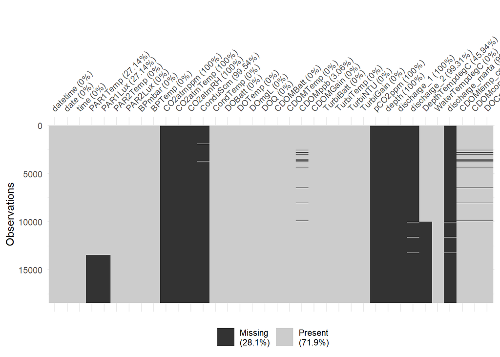

```r
vis_miss(vau_window)
```

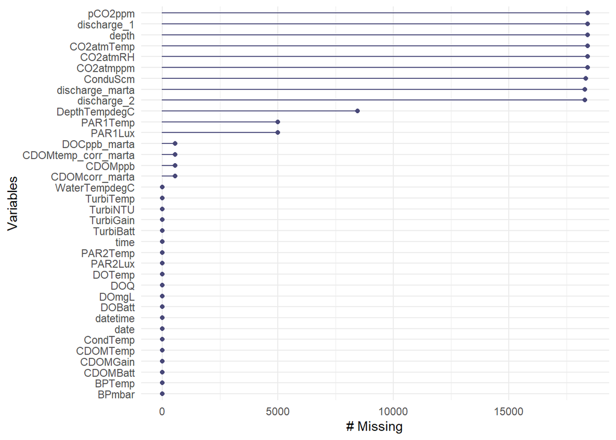

```r
gg_miss_var(vau_window)
```

Vis_miss produces a “heatmap” of the missingness - like as if the plot corresponded to the dataset as a giant spreadsheet, with values colored black for missing, and gray for present.

# 3. Data visualitzation

## 3.1. Time series plots using Base R

First we will start by making a multi-panel plot (2 plots one above the other one) with two distinct variables (only using the main y-axis):

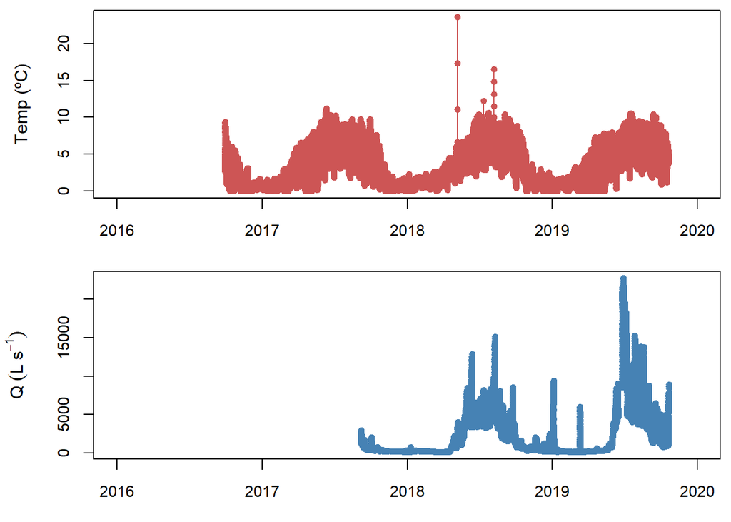

```r
par(mfrow= c(2,1), mar = c(3,4.5,0.5,0.5))
plot(vau$datetime,vau$DOTemp,cex=.25,cex.axis=0.9,type="n",xlab="",ylab="Temp (ºC)", main="")
lines(vau$datetime,vau$DOTemp,cex=0.75,lwd=1,lty=1,pch=21, type="o", col="Indian Red 3", bg="Indian Red 3")
plot(vau$datetime,vau$discharge_1,cex=.25,cex.axis=0.9,type="n",xlab="",ylab=expression(paste(Q~(L~s^-1))), main="")
lines(vau$datetime,vau$discharge_1,cex=0.75,lwd=1,lty=1,pch=21, type="o", col="Steel Blue", bg="Steel Blue")
```

Now we will make a multi-line plot (in one single panel) for one common variable but for different study sites.

```r
fed_all <- read_csv('00_course datasets/fed_all_2019.csv')
par(mfrow= c(1,1), mar = c(3,4.5,0.5,0.5))
plot(vau$datetime,vau$DOTemp,cex=.25,cex.axis=0.9,type="n",xlab="",ylab="Temp (ºC)", main="")
lines(vau$datetime,vau$DOTemp,cex=0.75,lwd=1,lty=1,pch=21, type="l", col="black")
adjustcolor( "red", alpha.f = 0.5)
```

```
## [1] "#FF000080"
```

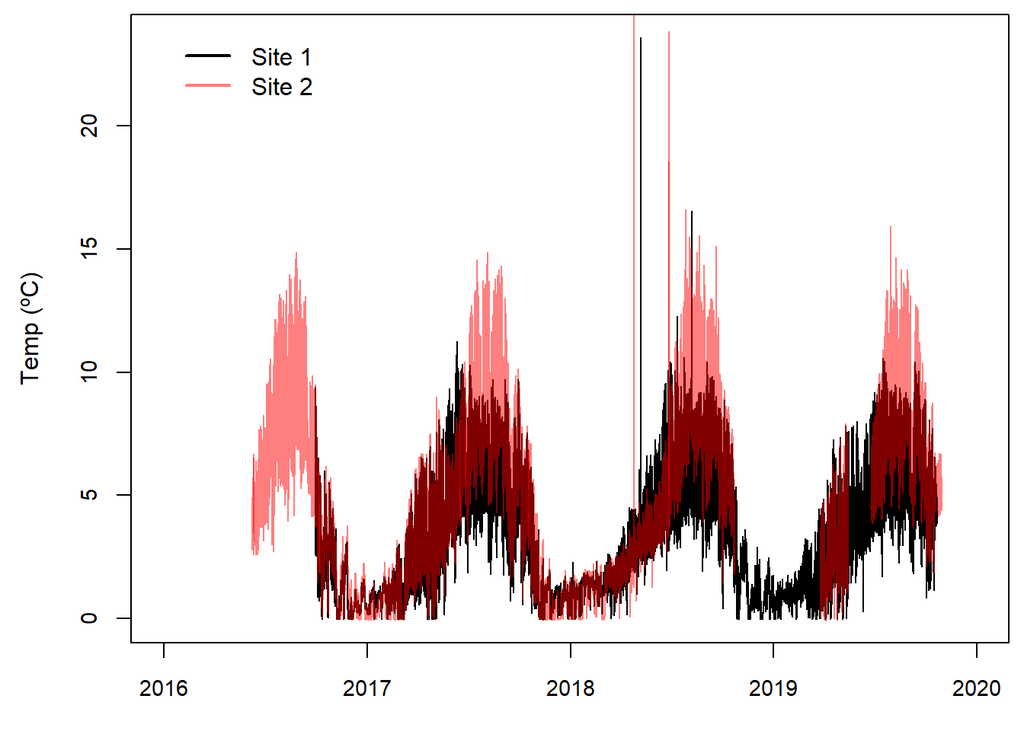

```r
lines(fed_all$datetime,fed_all$DOTemp,cex=0.75,lwd=1,lty=1,pch=21, type="l", col="#FF000080")

# Add a legend
legend(1451607000 ,24,
       legend = c("Site 1","Site 2"),
       lty=c(1,1),
       lwd=c(2,2),
       col = c("Black","#FF000080"),
       bty = "n")
```

Using the secondary y-axis:

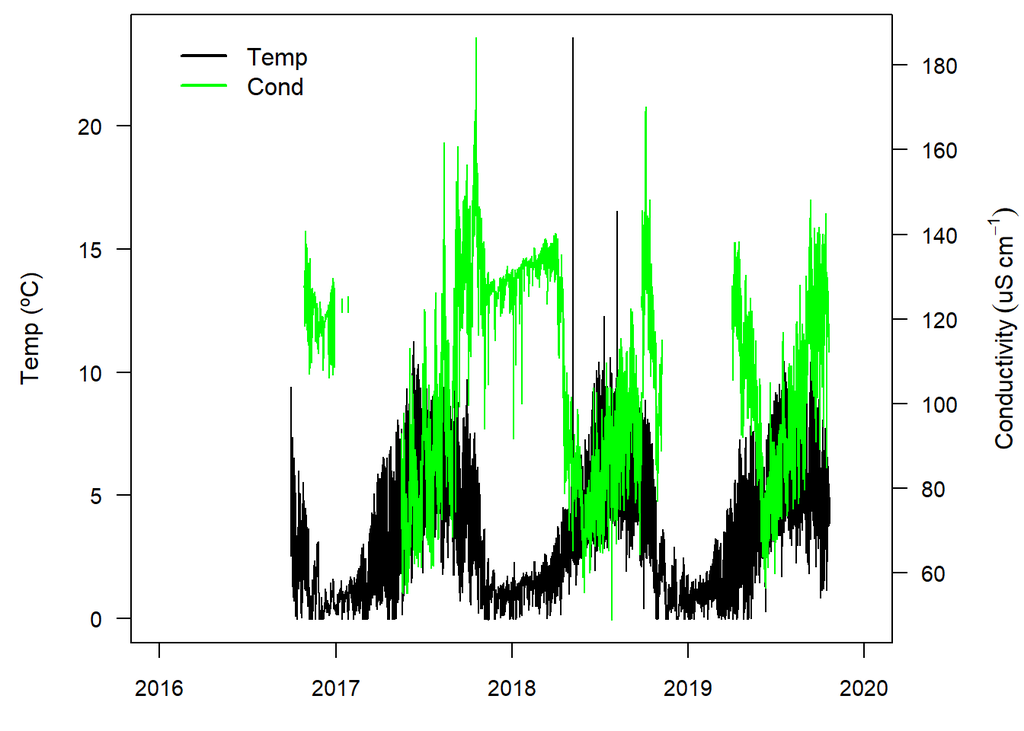

```r
par(mfrow= c(1,1), mar = c(3,4.5,0.5,4.5))
plot(vau$datetime,vau$DOTemp,cex=.25,cex.axis=0.9,type="n",xlab="",ylab="Temp (ºC)", main="", las=1)
lines(vau$datetime,vau$DOTemp,cex=0.75,lwd=1,lty=1,pch=21, type="l", col="black")

# Add a legend
legend(1451607000 ,24,
       legend = c("Temp","Cond"),
       lty=c(1,1),
       lwd=c(2,2),
       col = c("Black","green"),
       bty = "n")

par(new = TRUE) # Overimpose anew plot

# Add new plot
plot(vau$datetime,vau$ConduScm, lwd=1,lty=1,pch=21, type="l", col="green", axes = FALSE, xlab = "", ylab = "")
axis(4, ylim=c(0,1),col="black",las=1,cex.axis=0.9)  ## las=1 makes horizontal labels
mtext(expression(paste(Conductivity~(uS~cm^-1))), side = 4, line = 3.5) # Add second axis label
```

## 3.2. Time series plots using ggplot2

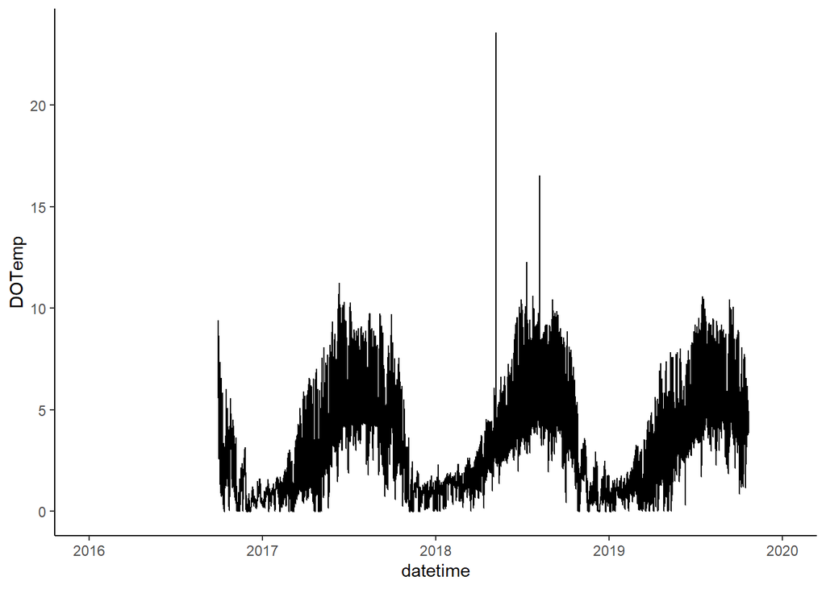

```r
ggplot(vau, aes(x=datetime, y=DOTemp)) +
  geom_line()+
  theme_classic()+
  scale_x_datetime(date_labels = "%Y") #"%Y/%m/%d"
```

Select specific window of time

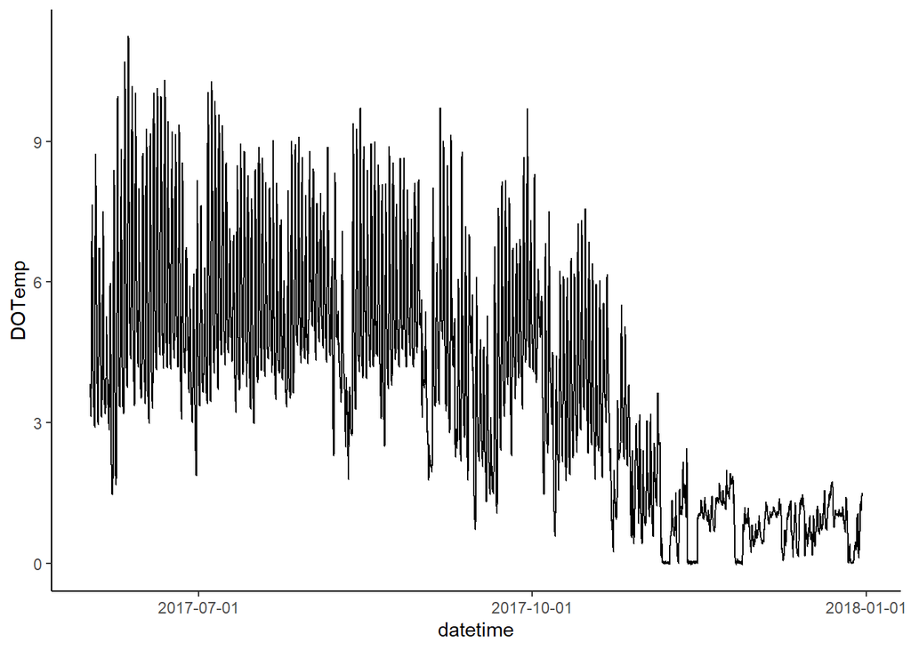

```r
datelimits <- as.POSIXct(c("2017-06-01", "2017-12-31"))

vau %>% filter(datetime > datelimits[1] & datetime < datelimits[2]) %>%
  ggplot(aes(datetime, DOTemp))+
  geom_line()+
  theme_classic()+
  scale_x_datetime(date_labels = "%Y-%m-%d")
```

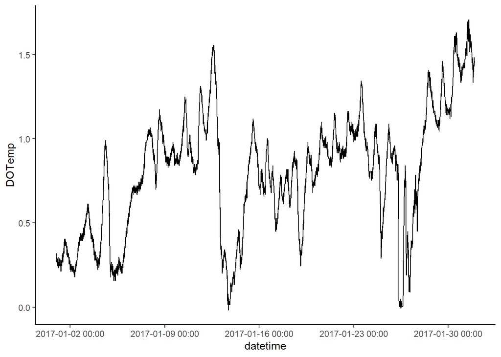

```r
datelimits <- as.POSIXct(c("2017-01-01", "2017-02-01"))

vau %>% filter(datetime > datelimits[1] & datetime < datelimits[2]) %>%
  ggplot(aes(datetime, DOTemp))+
  geom_line()+
  theme_classic()+
  scale_x_datetime(date_labels = "%Y-%m-%d %H:%M" )
```

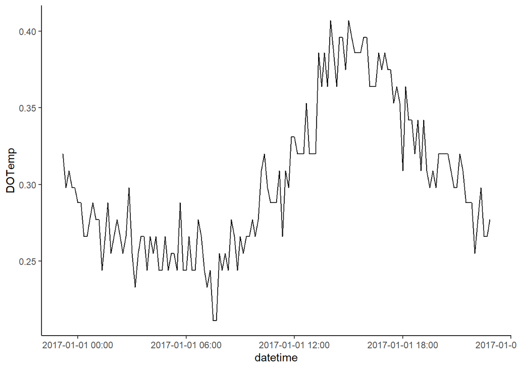

```r
datelimits <- as.POSIXct(c("2017-01-01", "2017-01-02"))

vau %>% filter(datetime > datelimits[1] & datetime < datelimits[2]) %>%
  ggplot(aes(datetime, DOTemp))+
  geom_line()+
  theme_classic()+
  scale_x_datetime(date_labels = "%Y-%m-%d %H:%M" )
```

Another option to subset time series:

```r
date1 <- as.Date("2017-08-01")
date2 <- as.Date("2017-08-05")
int <- interval(date1, date2)

vau_window<-vau[vau$date %within% int,]
```

## 3.3. Time agreggations

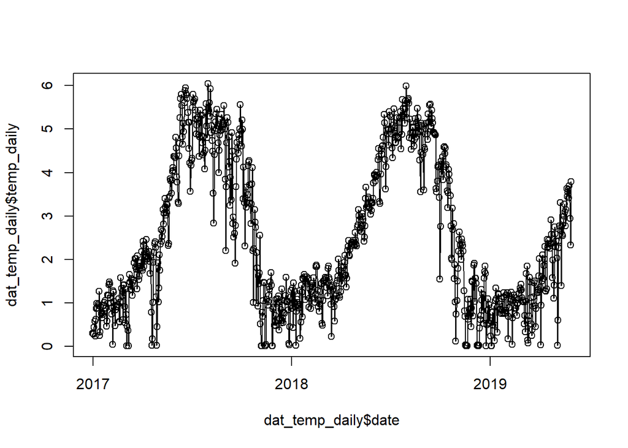

```r
datelimits <- as.POSIXct(c("2017-01-01", "2019-05-31"))
dat_limits<-vau %>% filter(datetime > datelimits[1] & datetime < datelimits[2])

dat_temp_daily<-dat_limits %>%
  group_by(date = cut(datetime, breaks="1 day")) %>%
  summarize(
    date = first(as.Date(datetime)),
    doy=yday(date),
    year=year(date),
    temp_daily = median(DOTemp,na.rm = TRUE))

plot(dat_temp_daily$date,dat_temp_daily$temp_daily, type="o")
```

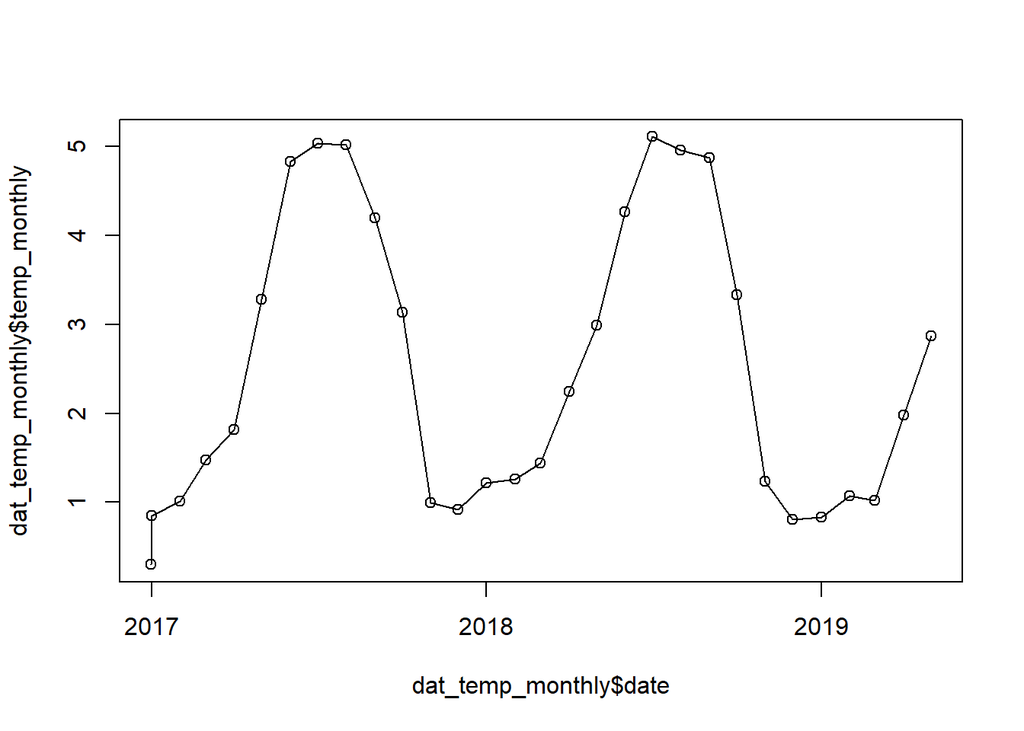

```r
dat_temp_monthly<-dat_limits %>%
  group_by(date = cut(datetime, breaks="1 month")) %>%
  summarize(
    date = first(as.Date(datetime)),
    doy=yday(date),
    year=year(date),
    temp_monthly = median(DOTemp,na.rm = TRUE))

plot(dat_temp_monthly$date,dat_temp_monthly$temp_monthly, type="o")
```

## 3.4. Heatmaps

### Example 1

Data preparation:

```r
a <- interp(x=dat_temp_daily$year, y=dat_temp_daily$doy, z=dat_temp_daily$temp_daily, duplicate = "mean",       xo=seq(min(dat_temp_daily$year),max(dat_temp_daily$year),by=1),
yo=seq(min(dat_temp_daily$doy),max(dat_temp_daily$doy),by=1))
```

Production of the heatmap:

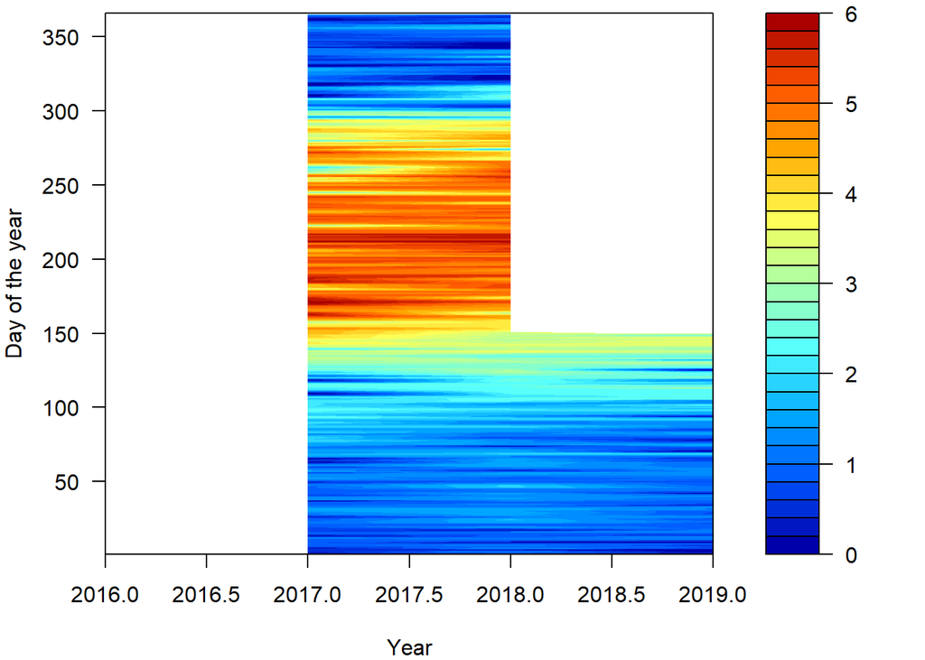

```r
# Color palettes:
cols<-matlab.like(250)
pal <- colorRampPalette(cols)

par(mfrow= c(1,1), mar = c(4,5,1,1))
par(oma = c(0, 0, 0, 0), mar = c(4, 4, 0.5, 0))

filled.contour(a,
               axes=TRUE,
               nlevels = 25, #50 best
               zlim = c(0,6),
               color.palette=pal,
               ylab = "Day of the year", xlab = "Year",
               frame.plot = TRUE,
               xlim=c(2016,2019),
               ylim=c(min(dat_temp_daily$doy),max(dat_temp_daily$doy)))
```

### Example 2

Read an external dataset:

```r
dat <- read_csv(paste0("00_course datasets/data_ebro/by_site/cinca.monzon",".csv"))
```

Subset the whole dataset by variable:

```r
dat_temp<-subset(dat,dat$variable=="wtemp.c")
dat_pH<-subset(dat,dat$variable=="pH")
dat_cond<-subset(dat,dat$variable=="cond25.uscm")
dat_do<-subset(dat,dat$variable=="do.mgl")
dat_nh4<-subset(dat,dat$variable=="nh4.mgL")
dat_level<-subset(dat,dat$variable=="level.saih.cm")
```

Select window of time (TIME WINDOW)

```r
datelimits <- as.POSIXct(c("1995-01-01", "2020-08-21"))
```

Create specific range based on time window

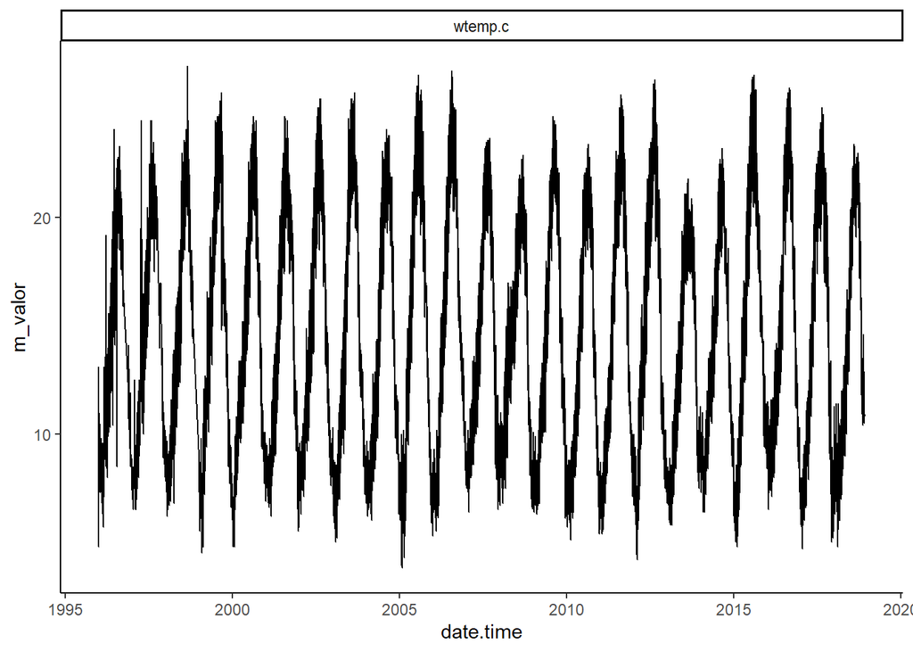

```r
mybreaks<-seq.Date(as.Date("1995-01-01"), as.Date("2020-08-21"), by="5 year")
mybreaks<-as.POSIXct(mybreaks, tz="GMT")

dat_temp %>% filter(date.time > datelimits[1] & date.time < datelimits[2]) %>%
  ggplot(aes(date.time, m_valor))+
  geom_line()+
  facet_wrap(~variable, scales = "free_y", ncol=1)+
  #geom_vline(xintercept = as.POSIXct("2020-01-01"), col="red")+
  theme_classic()+
  scale_x_datetime(breaks=mybreaks,date_labels = "%Y")
```

Aggregation of data (temperature time series)

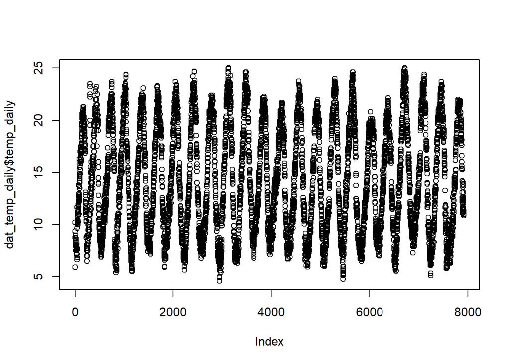

```r
dat_temp_limits<-dat_temp %>% filter(date.time > datelimits[1] & date.time < datelimits[2])

dat_temp_daily<-dat_temp_limits %>%
  group_by(date.time = cut(date.time, breaks="1 day")) %>%
  summarize(
    date = first(as.Date(date.time)),
    doy=yday(date),
    year=year(date),
    variable = first(variable),
    temp_daily = median(m_valor,na.rm = TRUE))

plot(dat_temp_daily$temp_daily)
```

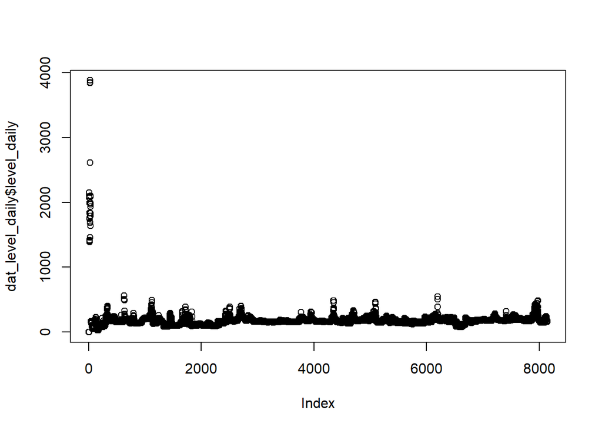

```r
dat_level_limits<-dat_level %>% filter(date.time > datelimits[1] & date.time < datelimits[2])

dat_level_daily<-dat_level_limits %>%
  group_by(date.time = cut(date.time, breaks="1 day")) %>%
  summarize(
    date = first(as.Date(date.time)),
    doy=yday(date),
    year=year(date),
    variable = first(variable),
    level_daily = median(m_valor,na.rm = TRUE))

plot(dat_level_daily$level_daily)
```

Data preparation:

```r
a <- interp(y=dat_temp_daily$year, x=dat_temp_daily$doy, z=dat_temp_daily$temp_daily, duplicate = "mean",
yo=seq(min(dat_temp_daily$year),max(dat_temp_daily$year),by=1),
xo=seq(min(dat_temp_daily$doy),max(dat_temp_daily$doy),by=1))
```

Production of the heatmap:

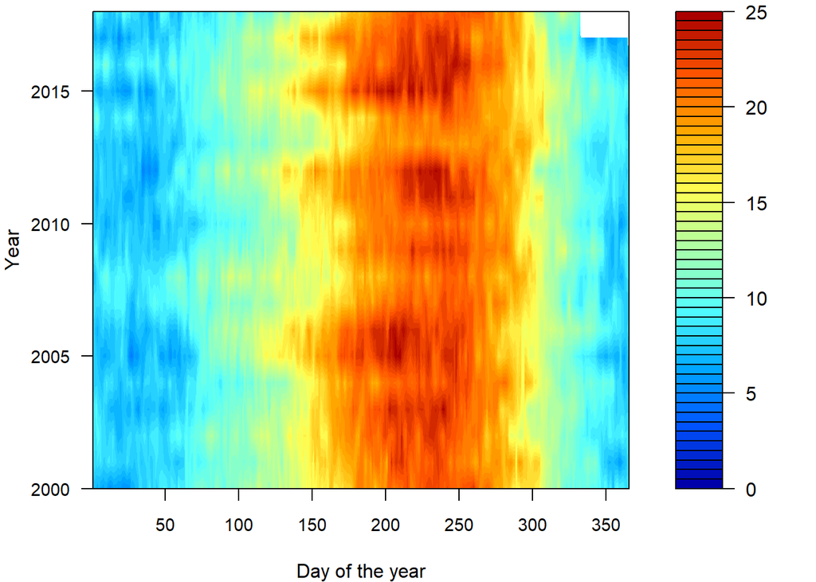

```r
# Color palettes:
cols<-matlab.like(250)
pal <- colorRampPalette(cols)

par(mfrow= c(1,1), mar = c(4,5,1,1))
par(oma = c(0, 0, 0, 0), mar = c(4, 4, 0.5, 0))

filled.contour(a,
               axes=TRUE,
               nlevels = 50, #50 best
               zlim = c(0,25),
               color.palette=pal,
               xlab = "Day of the year", ylab = "Year",
               plot.axes={
                 axis(1,cex.axis=0.9)
                 axis(2,cex.axis=0.9)},
               cex.lab=1,
               frame.plot = TRUE,
               ylim=c(2000,max(dat_temp_daily$year)),
               xlim=c(min(dat_temp_daily$doy),max(dat_temp_daily$doy)))
```

```r
a <- interp(y=dat_level_daily$year, x=dat_level_daily$doy, z=dat_level_daily$level_daily, duplicate = "mean",
yo=seq(min(dat_level_daily$year),max(dat_level_daily$year),by=1), xo=seq(min(dat_level_daily$doy),max(dat_level_daily$doy),by=1))
```

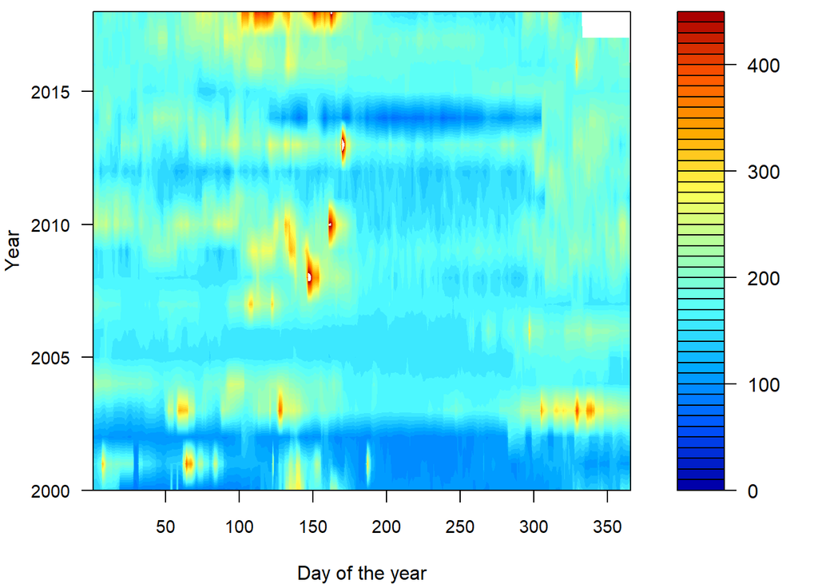

```r
# Color palettes:
cols<-matlab.like(250)
pal <- colorRampPalette(cols)

par(mfrow= c(1,1), mar = c(4,5,1,1))
par(oma = c(0, 0, 0, 0), mar = c(4, 4, 0.5, 0))

filled.contour(a,
               axes=TRUE,
               nlevels = 50, #50 best
               zlim = c(0,450),
               color.palette=pal,
               xlab = "Day of the year", ylab = "Year",
               plot.axes={
                 axis(1,cex.axis=0.9)
                 axis(2,cex.axis=0.9)},
               cex.lab=1,
               frame.plot = TRUE,
               ylim=c(2000,max(dat_level_daily$year)),
               xlim=c(min(dat_level_daily$doy),max(dat_level_daily$doy)))
```

## 3.5. Advanced visualitzation tools

*Streamflow Joyplot Tool* [Website](https://github.com/codeswitching/Streamflow-Joyplot-Tool).

*Streamflow Joyplot Tool (example 3D)* [Website](https://github.com/codeswitching/Streamflow-Joyplot-Tool/blob/master/plots/3d%20flow%20Green%20raytraced.png).

*Spiral plots with Spiralize Package* [Website](https://jokergoo.github.io/spiralize_vignettes/spiralize.html).

*Spiral plots (example NASA)* [Website](https://svs.gsfc.nasa.gov/4975).

## 3.6. Visualization of sensor time series for the general public

*VizLab USGS* [Website](https://labs.waterdata.usgs.gov/visualizations/vizlab-home/index.html#/).

[^1]: CREAF, gomez.gener87@gmail.com